# Dataquest: Guided Project: Creating An Efficient Data Analysis Workflow, Part 2

Ba Linh Le

# Introduction

The aim of this project is to figure out if the company’s new program helped to improve sales. The data is available here: https://data.world/dataquest/book-sales-data

```r
library(readr)
library(stringr)
library(dplyr)
library(lubridate)
library(tidyr)
library(ggplot2)
```

```r
dat <- read_csv("sales2019.csv")
```

# Exploration

```r
dim(dat)
```

```
## [1] 5000    5
```

```r
sapply(dat, class)
```

```
##                  date user_submitted_review                 title
##           "character"           "character"           "character"
##       total_purchased         customer_type
##             "numeric"           "character"
```

```r
colSums(is.na(dat))
```

```
##                  date user_submitted_review                 title
##                     0                   885                     0
##       total_purchased         customer_type
##                   718                     0
```

1. The dataset contains 5000 rows and 5 columns. The column names are: date, user_submitted_review, title, total_purchased, customer_type.
2. All columns except for total_purchased are character vectors. Total_purchased is of the numeric type.
3. There is missing data in user_submitted_review (885) and total_purchased (718).

# Data preparation

## Manage NA cases

```r
# Remove NA in user_submitted_review
dat1 <- dat %>%
  filter(!is.na(user_submitted_review))

# Calculate average number of books purchased
mean_purchase <-summarize(dat1, mean(total_purchased,
                                     na.rm = TRUE))

# Fill missing values in total_purchased with average number of books purchased
dat2 <- dat1 %>%
  mutate(
    total_p = unlist(ifelse(is.na(total_purchased),
                      round(mean_purchase,2),
                      total_purchased)))
```

## Classify text data

```r
# Examine unique cases in user_submitted_review
unique(dat2$user_submitted_review)
```

```
## [1] "it was okay"
## [2] "Awesome!"
## [3] "Hated it"
## [4] "Never read a better book"
## [5] "OK"
## [6] "The author's other books were better"
## [7] "A lot of material was not needed"
## [8] "Would not recommend"
## [9] "I learned a lot"
```

```r
# Function that takes in a sentence and returns a value indicating direction and degree of feedback

classify_review <- function(x) {
  positive_review = case_when(
    str_detect(x, "Awesome") ~ TRUE,
    str_detect(x, "lot") ~ TRUE,
    str_detect(x, "Never") ~ TRUE,
    str_detect(x, "Ok") ~ TRUE,
    TRUE ~ FALSE
  )
}

dat3 <- dat2 %>%
  mutate(positive = classify_review(user_submitted_review))
```

# Analysis

## Was the new book program effective in increasing book sales?

```r
# Conversion of date column to temporal data
dat3$date <- mdy(dat3$date)

# Create grouping column to distinguish between sales before and after July 1 2019
dat4 <- dat3 %>%
  mutate(
    program = case_when(
      date > "2019/07/01" ~ "After",
      date < "2019/07/01" ~ "Before")
  )

# Create summary table to compare number of books purchased before July 1, 2019 to after
dat4 %>% group_by(program) %>%
  summarize(total_books = sum(total_p))
```

```
## # A tibble: 3 x 2
##   program total_books
##   <chr>         <dbl>
## 1 After        8167.
## 2 Before       8212.
## 3 <NA>           24.0
```

The simple comparison shows that there is no substantial differences in book sales prior to and after the program implementation.

## Was the new book program effective in increasing book sales for subgroups?

```r
# Create summary table grouped by date and customer_type
dat4 %>% group_by(program, customer_type) %>%
  summarize(total_books = sum(total_p))
```

```
## # A tibble: 6 x 3
## # Groups:   program [3]
##   program customer_type total_books
##   <chr>   <chr>               <dbl>
## 1 After   Business           5732.
## 2 After   Individual         2435.
## 3 Before  Business           5613.
## 4 Before  Individual         2599.
## 5 <NA>    Business             11
## 6 <NA>    Individual           13.0
```

```r
# Create summary table grouped by date and customer_type
dat4 %>% group_by(program, title) %>%
  summarize(total_books = sum(total_p)) %>%
  pivot_wider(., names_from = program,
              values_from = total_books) %>%
  mutate(difference = After - Before) %>%
  arrange(desc(abs(difference)))
```

```
## # A tibble: 6 x 5
##   title                              After Before  `NA` difference
##   <chr>                              <dbl>  <dbl> <dbl>      <dbl>
## 1 Fundamentals of R For Beginners    2829.  3094.  3.99      -265.
## 2 Secrets Of R For Advanced Students 1148.   966.  7          182.
## 3 R For Dummies                      2770.  2626.  9          144.
## 4 R vs Python: An Essay              1169.  1271.  4         -102.
## 5 Top 10 Mistakes R Beginners Make    228.   241. NA          -13
## 6 R Made Easy                          24     15  NA            9
```

The book sales increased and decreased for some book titles. The biggest differences were reported by “Fundamentals of R For Beginners” (decrease by ca. 265 books) and the “Secrets of R for Advanced Students” (increase by ca. 182 books).

## Did review scores improve as a result of the program?

```r
# Create summary table to compare number of positive reviews before and after July 1, 2019
dat4 %>% group_by(program) %>%
  summarize(n = sum(positive))
```

```
## # A tibble: 3 x 2
##   program     n
##   <chr>   <int>
## 1 After     915
## 2 Before    852
## 3 <NA>        3
```

Book review scores improved slightly as a result of the program.

## Is there any relationship between month and the amount of books that were sold?

```r
# Classify months
dat5 <- dat4 %>%
  mutate(
    month = case_when(
      substr(dat4$date, 6, 7) == "01" ~ "January",
      substr(dat4$date, 6, 7) == "02" ~ "February",
      substr(dat4$date, 6, 7) == "03" ~ "March",
      substr(dat4$date, 6, 7) == "04" ~ "April",
      substr(dat4$date, 6, 7) == "05" ~ "May",
      substr(dat4$date, 6, 7) == "06" ~ "June",
      substr(dat4$date, 6, 7) == "07" ~ "July",
      substr(dat4$date, 6, 7) == "08" ~ "August",
      substr(dat4$date, 6, 7) == "09" ~ "September",
      substr(dat4$date, 6, 7) == "10" ~ "October",
      substr(dat4$date, 6, 7) == "11" ~ "November",
      substr(dat4$date, 6, 7) == "12" ~ "December",

    )
  )

# Create summary table to compare book sales per month
dat5 %>% group_by(month) %>%
  summarize(sum = sum(total_p)) %>%
  arrange(desc(sum))
```

```
## # A tibble: 12 x 2
##    month       sum
##    <chr>     <dbl>
##  1 December  1554.
##  2 July      1458.
##  3 March     1430.
##  4 April     1406.
##  5 June      1397.
##  6 January   1384.
##  7 May       1338.
##  8 August    1324.
##  9 November  1300.
## 10 September 1280.
## 11 October   1274.
## 12 February  1257.
```

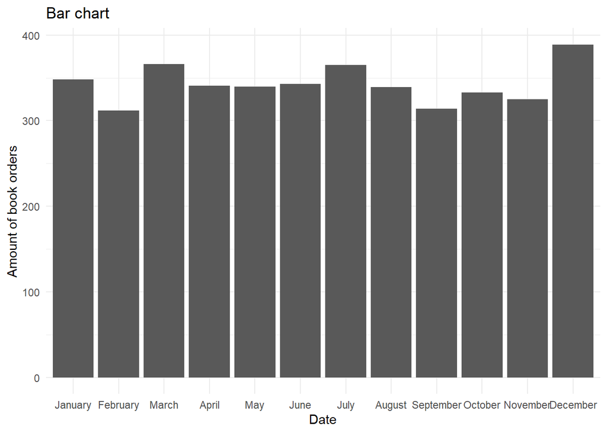

```r
# Scatterplot
dat5$month <- factor(dat5$month, levels = month.name)
ggplot(aes(x = month), data = dat5) +
  theme_minimal() +
  geom_bar() +
  xlab("Date") +
  ylab("Amount of book orders") +
  ggtitle("Bar chart")
```

Book sales appear to have decreased after the introduction of the program in July but increased again in December.